# Analysing The Most Harmful Climatic Shocks In The USA From 1950 to 2011

## Results

We are trying to answer tow questions:

1. Across the United States, which types of events (as indicated in the EVTYPE variable) are most harmful with respect to population health?
2. Across the United States, which types of events have the greatest economic consequences?

### Most harmful with respect to population health

If population health is impaired by fatalities and injuries, which events have the highest count of fatalities?

```r
#Grouping, summarizing and arranging fatalities and assigning them to a variable called fatal. We then highlight the top 10 fatalities and assign them to a variable called top.fatal.

fatal <- noaa3 %>% group_by(EVTYPE3) %>% summarize(total.fatalities=sum(FATALITIES)) %>%
    arrange(desc(total.fatalities))
top.fatal <- head(fatal, n=10)
top.fatal
```

```
## # A tibble: 10 × 2
##    EVTYPE3       total.fatalities
##    <chr>                    <dbl>
##  1 TORNADO                   5633
##  2 EXCESSIVEHEAT             1903
##  3 FLASHFLOOD                 978
##  4 HEAT                       937
##  5 LIGHTNING                  817
##  6 RIPCURRENT                 572
##  7 TSTMWIND                   505
##  8 FLOOD                      470
##  9 HIGHWIND                   248
## 10 AVALANCHE                  225
```

Viewing the `TSTMWIND` event type, we can see shortcomings of the data cleaning step - future research could try to do a better job here, but a quick glance at the numbers suggests that the top three (TORNADO, EXCESSIVEHEAT and FLASHFLOOD) will not be altered.

What events therefore cause the most injuries? Let’s use can use the same technique here:

```r
#Grouping, summarizing and arranging injuries and assigning them to a variable called injuries. We then highlight the top 10 injuries and assign them to a variable called top.injuries.
injuries <- noaa3 %>% group_by(EVTYPE3) %>% summarize(total.injuries=sum(INJURIES)) %>%
    arrange(desc(total.injuries))
top.injuries <- head(injuries, n=10)
top.injuries
```

```
## # A tibble: 10 × 2
##    EVTYPE3          total.injuries
##    <chr>                     <dbl>
##  1 TORNADO                   91364
##  2 TSTMWIND                   6961
##  3 FLOOD                      6789
##  4 EXCESSIVEHEAT              6525
##  5 LIGHTNING                  5230
##  6 HEAT                       2100
##  7 ICESTORM                   1975
##  8 FLASHFLOOD                 1777
##  9 THUNDERSTORMWIND           1488
## 10 HAIL                       1361
```

Here, again, shortcomings of my data cleaning step show up (“TSTMWIND”). It is still clear, though, that `TORNADO` is the big bad event!

Let’s show this graphically:

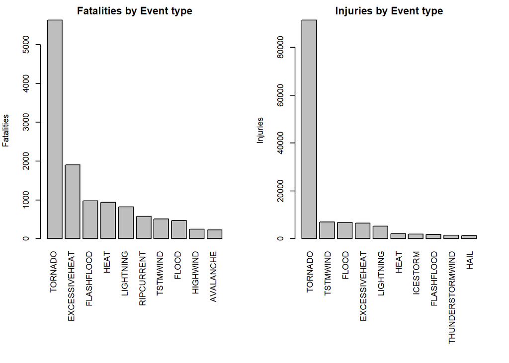

```r
#Using ggplot() function to graph this results as two panels within the same figure, we set  par(mfrow=c(1, 2), mar = c(12, 4, 2, 2.5), cex=0.7).

par(mfrow=c(1, 2), mar = c(12, 4, 2, 2.5), cex=0.7)
barplot(top.fatal$total.fatalities, names.arg=top.fatal$EVTYPE3, ylab= "Fatalities", las=3, main= "Fatalities by Event type")
barplot(top.injuries$total.injuries, names.arg=top.injuries$EVTYPE3, ylab="Injuries", las=3,
        main= "Injuries by Event type")
```

```r
png("replot1.png")
par(mfrow=c(1, 2), mar = c(12, 4, 2, 2.5), cex=0.7)
barplot(top.fatal$total.fatalities, names.arg=top.fatal$EVTYPE3, ylab= "Fatalities", las=3, main= "Fatalities by Event type")
barplot(top.injuries$total.injuries, names.arg=top.injuries$EVTYPE3, ylab="Injuries", las=3,
        main= "Injuries by Event type")
dev.off()
```

### Most harmful with respect to the economy

Next, we look at the cost of these events to the economy. We look at both property damage and damage to crops:

```r
#Grouping, summarizing and arranging property and assigning them to a variable called property. We then highlight the top 10 property damaged and assign them to a variable called top.property.
property <- noaa3 %>% group_by(EVTYPE3) %>% summarize(total.property.damage=sum(property.damage)) %>%
    arrange(desc(total.property.damage))
top.property <- head(property, n=10)
top.property
```

```
## # A tibble: 10 × 2
##    EVTYPE3          total.property.damage
##    <chr>                            <dbl>
##  1 FLOOD                    144657709807
##  2 HURRICANETYPHOON          69305840000
##  3 TORNADO                   56952151876.
##  4 STORMSURGE                43323536000
##  5 FLASHFLOOD                16823223978.
##  6 HAIL                      15735819513.
##  7 HURRICANE                 11868319010
##  8 TROPICALSTORM              7703890550
##  9 WINTERSTORM                6688497251
## 10 WILDFIRE                   5489714000
```

```r
#Grouping, summarizing and arranging crops and assigning them to a variable called crop. We then highlight the top 10 crop damaged and assign them to a variable called top.crop.
crop <- noaa3 %>% group_by(EVTYPE3) %>% summarize(total.crop.damage=sum(crop.damage)) %>%
    arrange(desc(total.crop.damage))
top.crop <- head(crop, n=10)
top.crop
```

```
## # A tibble: 10 × 2
##    EVTYPE3                total.crop.damage
##    <chr>                              <dbl>
##  1 HURRICANE                  802881916053
##  2 HURRICANETYPHOON           732768451330
##  3 FLOOD                       87251978368.
##  4 FLASHFLOOD                  38865139889.
##  5 TORNADO                     28269885712.
##  6 HAIL                        15316833978.
##  7 HURRICANEOPALHIGHWINDS      10000000000
##  8 TSTMWIND                     7684657862.
##  9 WILDFIRE                     7174309478.
## 10 HIGHWIND                     7174066263
```

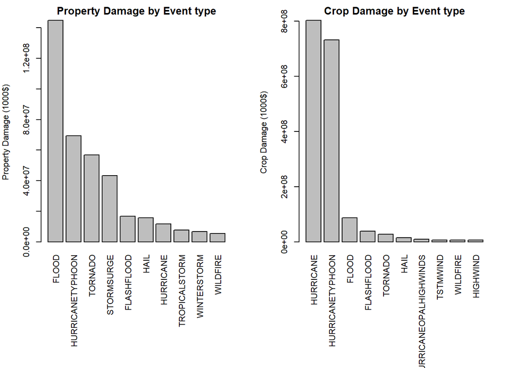

```r
#Using ggplot() function to graph this results as two panels within the same figure, we set  par(mfrow=c(1, 2), mar = c(12, 4, 2, 2.5), cex=0.7).

par(mfrow=c(1, 2), mar = c(12, 4, 2, 2.5), cex=0.7)
barplot(top.property$total.property.damage / 1000, names.arg=top.property$EVTYPE3, ylab='Property Damage (1000$)', las=3, main='Property Damage by Event type')
barplot(top.crop$total.crop.damage / 1000, names.arg=top.crop$EVTYPE3, ylab='Crop Damage (1000$)', las=3, main='Crop Damage by Event type')
```

```r
png("replot2.png")
par(mfrow=c(1, 2), mar = c(12, 4, 2, 2.5), cex=0.7)
barplot(top.property$total.property.damage / 1000, names.arg=top.property$EVTYPE3, ylab='Property Damage (1000$)', las=3, main='Property Damage by Event type')
barplot(top.crop$total.crop.damage / 1000, names.arg=top.crop$EVTYPE3, ylab='Crop Damage (1000$)', las=3, main='Crop Damage by Event type')

dev.off()
```

We can see that `HURRICANE` and `HURRICANETYPHOON` are both the most harmful event types for crops. These probably could even be lumped into a single event type `HURRICANE` (see data cleaning section).

We can also see that `FLOOD` causes the most property damage, with `HURRICANETYPHOON` and `TORNADO` among the top 3 too!

I would be interested in seeing how much these numbers change if I had time to reassign each event type to a smaller list (say, 20-30 types) by doing a more rigorous data cleaning.  
#1 might not change, though.

[output not shown]